# Week 11 Project: Machine Learning

# RStudio API Code

```r
library(rstudioapi)
setwd(dirname(rstudioapi::getActiveDocumentContext()$path))
```

# Libraries

```r
library(Hmisc)      # for importing spss data file
library(tidyverse)  # for data cleaning
library(caret)      # for processing data and performing cross-validation
library(knitr)      # for formatting tables
```

# Data Import and Cleaning

Steps:

1. Import data from SPSS data file
2. Select the personality and health variables
3. Convert “<NA>” labels into true NA values
   - Note that answers of 8 (don’t know), 9 (refused to answer), and 0 (not applicable) are all treated as missing values because these responses do not actually give us any information.
4. Remove observations that are missing all predictors or all predictors and response because these observations do not give us any information.
5. Convert all variables into numeric type.
6. Convert to a tibble instead of a data frame.

```r
# Import data from spss data file and select desired variables
gss_tbl <- spss.get("../data/GSS2006.sav") %>%
              select(starts_with("BIG5"), "HEALTH")  %>%
              mutate_all(.funs = function(x) ifelse(x == "<NA>", NA, x)) %>%
              # Rows missing 10 responses are missing all predictors
              # Rows missing 11 responses are missing all predictors and response
              # Want all the rows that do not have 10 or 11 responses missing
              filter(!(apply(., 1, function(x){sum(is.na(x))}) %in% c(10,11))) %>%
              mutate_all(as.numeric) %>%
              as_tibble()
```

# Analysis

Steps:

1. Set a seed for reproducible results
2. Preprocess the data
   - Use knn imputation to impute missing values; we use knn imputation since it has weaker assumptions on the type of missingness (MAR instead of MCAR).
   - Perform centering and scaling (done automatically as part of knn imputation)
3. Create a holdout sample and training sample.
4. Create 10 folds of the data so that all methods compared will use the exact same folds.
5. Fit the four different models using training data and test on holdout sample.
   - Ordinary Least Squares (OLS) Regression
   - Elastic Net Regression
   - Support Vector Machine (SVM) Regression
   - Extreme Gradient Boosted Regression

```r
# set the seed for reproducibility
set.seed(777)

# preprocessing of data
preprocess <- preProcess(gss_tbl, method = "knnImpute")
imputed_tbl <- predict(preprocess, gss_tbl)

# Create a holdout and training sample
rows <- sample(x = nrow(imputed_tbl), size = 250, replace = F)
holdout <- imputed_tbl[rows,]
train <- imputed_tbl[-rows, ]

# create 10 folds so that folds will be the same for all methods used
folds <-  createFolds(train$HEALTH, 10)

# Run OLS regression and compute 10-fold cv statistics
ols_model <- train(HEALTH ~ (.)^2,
                   data = train,
                   method = "lm",
                   trControl = trainControl(method = "cv",
                                            indexOut = folds,
                                            verboseIter = F)
)

ols_model
```

```
Linear Regression

1267 samples
  10 predictor

No pre-processing
Resampling: Cross-Validated (10 fold)
Summary of sample sizes: 1140, 1140, 1141, 1140, 1139, 1141, ...
Resampling results:

  RMSE       Rsquared    MAE
  0.9534626  0.07566406  0.7365796

Tuning parameter 'intercept' was held constant at a value of TRUE
```

```r
# Calculate holdout performance - MAE, RMSE, R squared
ols_holdout <- predict(ols_model, holdout)
ols.mae <- mean(abs(ols_holdout - holdout$HEALTH))
ols.rmse <- sqrt(mean((ols_holdout - holdout$HEALTH)^2))
ols.SSE <- sum((ols_holdout - holdout$HEALTH)^2)
ols.SST <- (nrow(holdout) - 1) * var(holdout$HEALTH)
ols.rsq <- 1-(ols.SSE/ols.SST)
ols.mae
```

```
[1] 0.779395
```

```r
ols.rmse
```

```
[1] 1.014742
```

```r
ols.rsq
```

```
[1] 0.0282996
```

```r
# Run elastic net regression
enet_model <- train(HEALTH ~ (.)^2,
                   data = train,
                   method = "glmnet",
                   trControl = trainControl(method = "cv",
                                            indexOut = folds,
                                            verboseIter = F)
)

enet_model
```

```
glmnet

1267 samples
  10 predictor

No pre-processing
Resampling: Cross-Validated (10 fold)
Summary of sample sizes: 1140, 1140, 1140, 1141, 1139, 1141, ...
Resampling results across tuning parameters:

  alpha  lambda        RMSE       Rsquared    MAE
  0.10   0.0002649677  0.9512936  0.07797633  0.7322935
  0.10   0.0026496769  0.9512464  0.07802167  0.7320841
  0.10   0.0264967695  0.9507681  0.07867591  0.7285020
  0.55   0.0002649677  0.9512975  0.07797209  0.7323184
  0.55   0.0026496769  0.9510121  0.07826060  0.7308976
  0.55   0.0264967695  0.9544260  0.07528790  0.7209646
  1.00   0.0002649677  0.9512793  0.07799200  0.7322405
  1.00   0.0026496769  0.9508602  0.07847676  0.7297421
  1.00   0.0264967695  0.9622438  0.06428463  0.7175400

RMSE was used to select the optimal model using the smallest value.
The final values used for the model were alpha = 0.1 and lambda = 0.02649677.
```

```r
# Calculate holdout performance - MAE, RMSE, R squared
enet_holdout <- predict(enet_model, holdout)
enet.mae <- mean(abs(enet_holdout - holdout$HEALTH))
enet.rmse <- sqrt(mean((enet_holdout - holdout$HEALTH)^2))
enet.SSE <- sum((enet_holdout - holdout$HEALTH)^2)
enet.SST <- (nrow(holdout) - 1) * var(holdout$HEALTH)
enet.rsq <- 1-(enet.SSE/enet.SST)
enet.mae
```

```
[1] 0.7743588
```

```r
enet.rmse
```

```
[1] 1.013381
```

```r
enet.rsq
```

```
[1] 0.03090468
```

```r
# Run SVM regression
svm_model <- train(HEALTH ~ (.)^2,
                   data = train,
                   method = "svmLinear2",
                   trControl = trainControl(method = "cv",
                                            indexOut = folds,
                                            verboseIter = F)
)

svm_model
```

```
Support Vector Machines with Linear Kernel

1267 samples
  10 predictor

No pre-processing
Resampling: Cross-Validated (10 fold)
Summary of sample sizes: 1140, 1140, 1141, 1141, 1141, 1140, ...
Resampling results across tuning parameters:

  cost  RMSE       Rsquared    MAE
  0.25  0.9633819  0.06854600  0.7112288
  0.50  0.9634324  0.06841889  0.7112597
  1.00  0.9633802  0.06859790  0.7112366

RMSE was used to select the optimal model using the smallest value.
The final value used for the model was cost = 1.
```

```r
# Calculate holdout performance - MAE, RMSE, R squared
svm_holdout <- predict(svm_model, holdout)
svm.mae <- mean(abs(svm_holdout - holdout$HEALTH))
svm.rmse <- sqrt(mean((svm_holdout - holdout$HEALTH)^2))
svm.SSE <- sum((svm_holdout - holdout$HEALTH)^2)
svm.SST <- (nrow(holdout) - 1) * var(holdout$HEALTH)
svm.rsq <- 1-(svm.SSE/svm.SST)
svm.mae
```

```
[1] 0.7743244
```

```r
svm.rmse
```

```
[1] 1.029022
```

```r
svm.rsq
```

```
[1] 0.0007583564
```

```r
# Run extreme gradient boosted regression
egb_model <- train(HEALTH ~ (.)^2,
                   data = train,
                   method = "xgbLinear",
                   trControl = trainControl(method = "cv",
                                            indexOut = folds,
                                            verboseIter = F)
)

egb_model
```

```
eXtreme Gradient Boosting

1267 samples
  10 predictor

No pre-processing
Resampling: Cross-Validated (10 fold)
Summary of sample sizes: 1139, 1140, 1139, 1141, 1140, 1141, ...
Resampling results across tuning parameters:

  lambda  alpha  nrounds  RMSE       Rsquared   MAE
  0e+00   0e+00   50      0.4317410  0.8108158  0.2355235
  0e+00   0e+00  100      0.3949297  0.8397539  0.1624414
  0e+00   0e+00  150      0.3913978  0.8430952  0.1411878
  0e+00   1e-04   50      0.4442288  0.7992349  0.2453231
  0e+00   1e-04  100      0.4067629  0.8295654  0.1678378
  0e+00   1e-04  150      0.4050849  0.8318964  0.1451278
  0e+00   1e-01   50      0.4338324  0.8090368  0.2399063
  0e+00   1e-01  100      0.3940150  0.8400514  0.1644516
  0e+00   1e-01  150      0.3906965  0.8430184  0.1445632
  1e-04   0e+00   50      0.4442567  0.7994900  0.2419650
  1e-04   0e+00  100      0.4079289  0.8290443  0.1684962
  1e-04   0e+00  150      0.4029791  0.8337352  0.1452067
  1e-04   1e-04   50      0.4428129  0.8006334  0.2457720
  1e-04   1e-04  100      0.4027015  0.8331470  0.1672982
  1e-04   1e-04  150      0.3988956  0.8368986  0.1439393
  1e-04   1e-01   50      0.4345386  0.8086229  0.2397347
  1e-04   1e-01  100      0.3995285  0.8357470  0.1664038
  1e-04   1e-01  150      0.3953426  0.8395708  0.1460172
  1e-01   0e+00   50      0.4413617  0.8027629  0.2442744
  1e-01   0e+00  100      0.3981130  0.8378421  0.1641512
  1e-01   0e+00  150      0.3940100  0.8416313  0.1414328
  1e-01   1e-04   50      0.4410168  0.8030367  0.2399388
  1e-01   1e-04  100      0.4047476  0.8331038  0.1658476
  1e-01   1e-04  150      0.4017803  0.8361227  0.1437617
  1e-01   1e-01   50      0.4270096  0.8153382  0.2360135
  1e-01   1e-01  100      0.3905918  0.8421016  0.1626605
  1e-01   1e-01  150      0.3885664  0.8436052  0.1444120

Tuning parameter 'eta' was held constant at a value of 0.3
RMSE was used to select the optimal model using the smallest value.
The final values used for the model were nrounds = 150, lambda = 0.1, alpha = 0.1 and eta = 0.3.
```

```r
# Calculate holdout performance - MAE, RMSE, R squared
egb_holdout <- predict(egb_model, holdout)
egb.mae <- mean(abs(egb_holdout - holdout$HEALTH))
egb.rmse <- sqrt(mean((egb_holdout - holdout$HEALTH)^2))
egb.SSE <- sum((egb_holdout - holdout$HEALTH)^2)
egb.SST <- (nrow(holdout) - 1) * var(holdout$HEALTH)
egb.rsq <- 1-(egb.SSE/egb.SST)
egb.mae
```

```
[1] 0.9575673
```

```r
egb.rmse
```

```
[1] 1.203474
```

```r
egb.rsq
```

```
[1] -0.3667674
```

```r
# Compre the results of the 10-fold cross-validation
compare <- summary(resamples(list("OLS Regression" = ols_model,
               "Elastic Net Regression" = enet_model,
               "Support Vector Regression" = svm_model,
               "Extreme Gradient Boosting" = egb_model)))

MAE <- c(1,4,7,10)
RMSE <- c(2,5,8,11)
RSq <- c(3,6,9,12)

# Table of Mean Absolute Error
kable(rbind("Minimum" = apply(compare$values[,MAE], 2, min),
            "Mean" = apply(compare$values[,MAE], 2, mean),
            "Median" = apply(compare$values[,MAE], 2, median),
            "Maximum" = apply(compare$values[,MAE], 2, max)),
      col.names = compare$models,
      align = "c",
      caption = "Mean Absolute Error",
      format = "pandoc",
      digits = 3)
```

Mean Absolute Error

|  | OLS Regression | Elastic Net Regression | Support Vector Regression | Extreme Gradient Boosting |
| --- | --- | --- | --- | --- |
| Minimum | 0.628 | 0.629 | 0.613 | 0.077 |
| Mean | 0.737 | 0.729 | 0.711 | 0.144 |
| Median | 0.746 | 0.741 | 0.716 | 0.145 |
| Maximum | 0.826 | 0.811 | 0.796 | 0.202 |

```r
# Table of Root Mean Square Error
kable(rbind("Minimum" = apply(compare$values[,RMSE], 2, min),
            "Mean" = apply(compare$values[,RMSE], 2, mean),
            "Median" = apply(compare$values[,RMSE], 2, median),
            "Maximum" = apply(compare$values[,RMSE], 2, max)),
      col.names = compare$models,
      align = "c",
      caption = "Root Mean Square Error",
      format = "pandoc",
      digits = 3)
```

Root Mean Square Error

|  | OLS Regression | Elastic Net Regression | Support Vector Regression | Extreme Gradient Boosting |
| --- | --- | --- | --- | --- |
| Minimum | 0.833 | 0.829 | 0.847 | 0.226 |
| Mean | 0.953 | 0.951 | 0.963 | 0.389 |
| Median | 0.965 | 0.965 | 0.965 | 0.410 |
| Maximum | 1.057 | 1.049 | 1.064 | 0.516 |

```r
# Table of R squared
kable(rbind("Minimum" = apply(compare$values[,RSq], 2, min),
            "Mean" = apply(compare$values[,RSq], 2, mean),
            "Median" = apply(compare$values[,RSq], 2, median),
            "Maximum" = apply(compare$values[,RSq], 2, max)),
      col.names = compare$models,
      align = "c",
      caption = "R-Squared",
      format = "pandoc",
      digits = 3)
```

R-Squared

|  | OLS Regression | Elastic Net Regression | Support Vector Regression | Extreme Gradient Boosting |
| --- | --- | --- | --- | --- |
| Minimum | 0.022 | 0.031 | 0.015 | 0.751 |
| Mean | 0.076 | 0.079 | 0.069 | 0.844 |
| Median | 0.055 | 0.061 | 0.055 | 0.829 |
| Maximum | 0.153 | 0.171 | 0.149 | 0.936 |

```r
# Table of Holdout Sample Values
kable(rbind("OLS Regression" = c(ols.mae, ols.rmse, ols.rsq),
            "Elastic Net Regression" = c(enet.mae, enet.rmse, enet.rsq),
            "Support Vector Regression" = c(svm.mae, svm.rmse, svm.rsq),
            "Extreme Gradient Boosting" = c(egb.mae, egb.rmse, egb.rsq)),
      col.names = c("MAE", "RMSE", "R-Squared"),
      align = "c",
      caption = "Holdout Sample Performance",
      digits = 3,
      format = "pandoc")
```

Holdout Sample Performance

|  | MAE | RMSE | R-Squared |
| --- | --- | --- | --- |
| OLS Regression | 0.779 | 1.015 | 0.028 |
| Elastic Net Regression | 0.774 | 1.013 | 0.031 |
| Support Vector Regression | 0.774 | 1.029 | 0.001 |
| Extreme Gradient Boosting | 0.958 | 1.203 | -0.367 |

To calculate the root mean square error (RMSE), we determine how far off the predicted values are from the true values, square that value, take the mean of all of those values, and finally take the square root. This gives us a measure of how close to the true value the prediction is. This metric is reported in standard deviation units since the data are centered and scaled. Smaller values indicate better performance.

To calculate the mean absolute error (MAE), we take the absolute value of the difference between the true and predicted scores and then take the mean of all of those values. Again, the unit is in terms of standard deviation because the variables are centered and scaled. Again, smaller values indicate better performance.

The $R^2$ value is determined by taking $1 - \frac{SSE}{SST}$ where SSE is the sum of the squared errors between the true and predicted values and SST is $(N-1)*var(Y)$. Here the variance of Y is the variance in the observed HEALTH variables. $R^2$ can be interpreted as the amount of variation in the response variable that can be accounted for by the predictors. In this case, larger values indicate better performance. A negative $R^2$ in a holdout sample indicates that the model predicts worse than chance.

The results of the OLS regression, elastic net regression, and support vector regression are all very similar in terms of the cross-validated error statistics. The extreme gradient boosting model had much lower MAE and RMSE and much higher $R^2$ values than the other three models. I think that these results are due to extreme gradient boosting being an ensemble method whereas the others are not. The extreme gradient boosting model is a combination of a lot of simpler base models of the same type, and the other three methods are a base model themselves.

The tuning parameters that worked best for the elastic net are $\alpha$ = 0.1 and $\lambda$ = 0.02649677. This $\alpha$ parameter means that the regression is 10% Lasso and 90% ridge regression. The $\lambda$ controls how much regularization occurs; since it is pretty small, there is not much regularization.

# Visualization

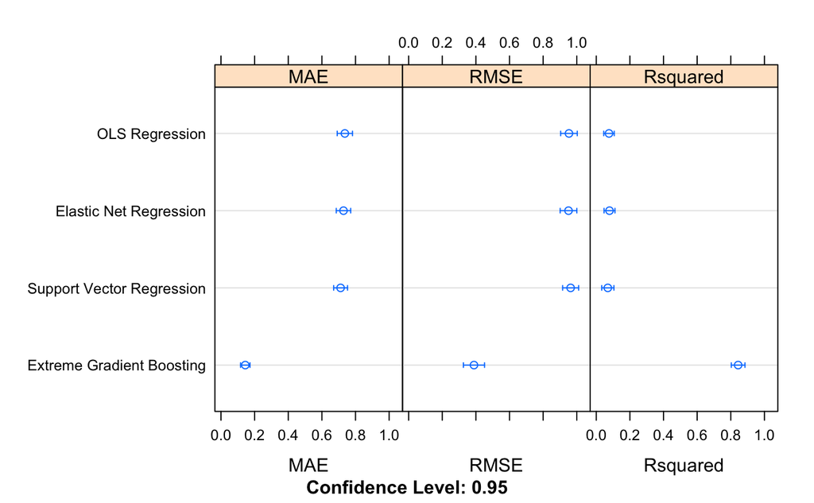

```r
# 10-fold CV performance comparison across models
dotplot(resamples(list("OLS Regression" = ols_model,
                       "Elastic Net Regression" = enet_model,
                       "Support Vector Regression" = svm_model,
                       "Extreme Gradient Boosting" = egb_model)))
```

There are some tradeoffs between the models. The OLS runs the fastest followed by elastic net and support vector regression. The slowest by far is the extreme gradient boosting because it is an ensemble approach and has more parameters to tune. If speed is an issue, one might select the OLS regression. The OLS regression model is probably the easiest to interpret, so one may choose the OLS regression if the goal is interpretability. The extreme gradient boosting allows for more flexible models, but it is more likely to overfit the data as seen in this project.